# Anexo. Ejemplo simplificado de ontología y grafo de conocimiento

Representación básica de un activo turístico con R

Equipo UIB - MoDAE (IAIB) - PID

22/05/2026

# 1 Introducción

Este anexo muestra, de forma simplificada, cómo puede representarse un activo turístico con una ontología y transformar en un pequeño grafo de conocimiento.

El objetivo no es sustituir la arquitectura real de la Plataforma Inteligente de Destinos (PID), ni reproducir de forma completa la Ontología del Turismo de SEGITTUR. El objetivo es mostrar de manera comprensible cómo una ontología define clases y relaciones, y cómo un grafo permite representar activos concretos siguiendo esa estructura.

La idea central es la siguiente:

> La ontología define el significado.  
> El grafo conecta los datos reales siguiendo ese significado.

En este ejemplo se usa el activo turístico **Playa de Muro**. Podría sustituirse por cualquier otro activo del catálogo MO-4: un museo, una oficina de turismo, una ruta, un evento, un alojamiento o un servicio público.

# 2 Preparación del entorno

Prepara el entorno de R con los paquetes necesarios para construir y visualizar el grafo. Si no los tienes instalados, descomenta las líneas de instalación.

```r
# Paquetes necesarios para construir y visualizar el grafo.
# Si no están instalados, descomenta las líneas siguientes:

# install.packages("igraph")
# install.packages("tibble")
# install.packages("dplyr")

library(igraph)
library(tibble)
library(dplyr)
```

## 2.1 Idea conceptual

Una ontología turística funciona como un **lenguaje común** para describir el destino. Define clases, propiedades y relaciones.

Por ejemplo:

- una **playa** puede ser un tipo de **recurso de interés turístico**;
- un **hotel** puede ser un tipo de **alojamiento**;
- una **oficina de turismo** puede ser un tipo de **servicio público**;
- un **evento** puede celebrarse en un municipio o en un recurso concreto;
- un activo turístico puede tener localización, horario, descripción, multimedia, accesibilidad, idioma disponible y canales de publicación.

El grafo de conocimiento representa casos concretos siguiendo esa lógica. Así, **Playa de Muro** deja de ser solo una fila en una tabla y pasa a ser un nodo conectado con municipio, servicios, canales digitales, indicadores y otros activos.

## 2.2 Definición de nodos

En un grafo, los **nodos** representan entidades.

En este ejemplo mezclamos tres tipos de nodos:

1. **Clases ontológicas**, como `Recurso turístico` o `Playa`.
2. **Instancias concretas**, como `Playa de Muro`.
3. **Entidades relacionadas**, como municipio, servicios, canales digitales o indicadores.

```r
# Tabla de nodos del grafo.
# Cada fila representa una entidad.
#
# El prefijo "seg:" se usa aquí para representar clases inspiradas
# en la Ontología del Turismo de SEGITTUR.
#
# El prefijo "mo4:" se usa para representar entidades concretas
# de un catálogo imaginario MO-4 de Mallorca.
#
# Esto es solo una convención didáctica para el ejemplo.

nodes <- tribble(
  ~id,                         ~label,                         ~tipo,
  "seg:RecursoTuristico",      "Recurso de interés turístico", "Clase ontológica",
  "seg:Playa",                 "Playa",                        "Clase ontológica",
  "seg:Evento",                "Evento",                       "Clase ontológica",
  "mo4:PlayaDeMuro",           "Playa de Muro",                "Activo MO-4",
  "mo4:MunicipioMuro",         "Municipio de Muro",            "Territorio",
  "mo4:Socorrismo",            "Servicio de socorrismo",       "Servicio público",
  "mo4:Aparcamiento",          "Aparcamiento cercano",         "Servicio",
  "mo4:Accesibilidad",         "Accesibilidad parcial",        "Atributo",
  "mo4:Imagenes",              "Imágenes y multimedia",        "Contenido",
  "mo4:AppTurista",            "App Turista",                  "Canal digital",
  "mo4:PortalDestino",         "Portal Destino",               "Canal digital",
  "mo4:IndicadorSaturacion",   "Indicador de saturación",      "Indicador"
)
nodes
```

```
## # A tibble: 12 × 3
##    id                      label                        tipo
##    <chr>                   <chr>                        <chr>
##  1 seg:RecursoTuristico    Recurso de interés turístico Clase ontológica
##  2 seg:Playa               Playa                        Clase ontológica
##  3 seg:Evento              Evento                       Clase ontológica
##  4 mo4:PlayaDeMuro         Playa de Muro                Activo MO-4
##  5 mo4:MunicipioMuro       Municipio de Muro            Territorio
##  6 mo4:Socorrismo          Servicio de socorrismo       Servicio público
##  7 mo4:Aparcamiento        Aparcamiento cercano         Servicio
##  8 mo4:Accesibilidad       Accesibilidad parcial        Atributo
##  9 mo4:Imagenes            Imágenes y multimedia        Contenido
## 10 mo4:AppTurista          App Turista                  Canal digital
## 11 mo4:PortalDestino       Portal Destino               Canal digital
## 12 mo4:IndicadorSaturacion Indicador de saturación      Indicador
```

# 3 Definición de relaciones

En un grafo, las **aristas** representan relaciones entre nodos.

En términos semánticos, cada relación puede entenderse como un triple:

> sujeto — predicado — objeto

Por ejemplo:

> Playa de Muro — está en — Municipio de Muro

> Playa de Muro — es un tipo de — Playa

> Playa de Muro — dispone de — Servicio de socorrismo

# 4 Objetivo del ejemplo

Este documento muestra un ejemplo sencillo de cómo representar un activo turístico del módulo MO-4 de la PID Mallorca mediante un grafo de conocimiento.

El ejemplo utiliza una playa concreta, la **Playa de Muro**, y la conecta con clases generales inspiradas en la Ontología del Turismo de SEGITTUR, así como con servicios, atributos, contenidos digitales, canales de publicación e indicadores.

El objetivo no es construir una ontología completa, sino mostrar de forma didáctica cómo un activo turístico puede dejar de ser un registro aislado en una tabla y pasar a representarse como una entidad conectada dentro de una infraestructura semántica de datos.

# 5 Carga de librerías

```r
library(tidyverse)
library(tidygraph)
library(ggraph)
library(grid)

# Paleta común para los grafos.
# Se usa fondo blanco, marco exterior y etiquetas rectangulares coloreadas,
# siguiendo el estilo de los PNG de referencia pero mejorando su legibilidad en documento.
colores_tipo <- c(
  "Clase ontológica" = "#31c400",
  "Activo MO-4"      = "#ff746d",
  "Territorio"       = "#ff55c8",
  "Servicio público" = "#d96af2",
  "Servicio"         = "#7fa8ff",
  "Atributo"         = "#e3a900",
  "Contenido"        = "#10c3ad",
  "Canal digital"    = "#b4bd00",
  "Indicador"        = "#00b9e8",
  "Evento MO-4"      = "#00b9bd"
)

tema_grafo_mo4 <- function() {
  theme_void() +
    theme(
      # Fondo blanco para que el grafo se integre mejor en el anexo.
      plot.background = element_rect(fill = "white", colour = "black", linewidth = 0.9),
      panel.background = element_rect(fill = "white", colour = NA),
      # Marco interior alrededor del dibujo del grafo.
      panel.border = element_rect(fill = NA, colour = "black", linewidth = 0.8),
      plot.title = element_text(colour = "black", face = "bold", size = 17, hjust = 0.5),
      plot.subtitle = element_text(colour = "grey30", size = 12, hjust = 0.5),
      plot.margin = margin(25, 65, 25, 65),
      legend.position = "none"
    )
}
```

## 5.1 Tabla de nodos

Cada fila representa una entidad del grafo.

El prefijo `seg:` se usa aquí para representar clases inspiradas en la Ontología del Turismo de SEGITTUR.

El prefijo `mo4:` se usa para representar entidades concretas del catálogo imaginario MO-4 de Mallorca.

Esto es solo una convención didáctica para el ejemplo.

```r
nodes <- tribble(
  ~id,                         ~label,                         ~tipo,
  "seg:RecursoTuristico",      "Recurso de interés turístico", "Clase ontológica",
  "seg:Playa",                 "Playa",                        "Clase ontológica",
  "seg:Evento",                "Evento",                       "Clase ontológica",
  "mo4:PlayaDeMuro",           "Playa de Muro",                "Activo MO-4",
  "mo4:MunicipioMuro",         "Municipio de Muro",            "Territorio",
  "mo4:Socorrismo",            "Servicio de socorrismo",       "Servicio público",
  "mo4:Aparcamiento",          "Aparcamiento cercano",         "Servicio",
  "mo4:Accesibilidad",         "Accesibilidad parcial",        "Atributo",
  "mo4:Imagenes",              "Imágenes y multimedia",        "Contenido",
  "mo4:AppTurista",            "App Turista",                  "Canal digital",
  "mo4:PortalDestino",         "Portal Destino",               "Canal digital",
  "mo4:IndicadorSaturacion",   "Indicador de saturación",      "Indicador"
)

nodes
```

```
## # A tibble: 12 × 3
##    id                      label                        tipo
##    <chr>                   <chr>                        <chr>
##  1 seg:RecursoTuristico    Recurso de interés turístico Clase ontológica
##  2 seg:Playa               Playa                        Clase ontológica
##  3 seg:Evento              Evento                       Clase ontológica
##  4 mo4:PlayaDeMuro         Playa de Muro                Activo MO-4
##  5 mo4:MunicipioMuro       Municipio de Muro            Territorio
##  6 mo4:Socorrismo          Servicio de socorrismo       Servicio público
##  7 mo4:Aparcamiento        Aparcamiento cercano         Servicio
##  8 mo4:Accesibilidad       Accesibilidad parcial        Atributo
##  9 mo4:Imagenes            Imágenes y multimedia        Contenido
## 10 mo4:AppTurista          App Turista                  Canal digital
## 11 mo4:PortalDestino       Portal Destino               Canal digital
## 12 mo4:IndicadorSaturacion Indicador de saturación      Indicador
```

## 5.2 Tabla de relaciones

Cada fila representa una relación entre dos nodos.

La columna `from` indica el nodo origen.

La columna `to` indica el nodo destino.

La columna `relacion` indica el tipo de relación semántica.

```r
edges <- tribble(
  ~from,                       ~to,                         ~relacion,
  "seg:Playa",                 "seg:RecursoTuristico",      "subclase_de",
  "mo4:PlayaDeMuro",           "seg:Playa",                 "es_un_tipo_de",
  "mo4:PlayaDeMuro",           "mo4:MunicipioMuro",         "se_localiza_en",
  "mo4:PlayaDeMuro",           "mo4:Socorrismo",            "dispone_de",
  "mo4:PlayaDeMuro",           "mo4:Aparcamiento",          "dispone_de",
  "mo4:PlayaDeMuro",           "mo4:Accesibilidad",         "tiene_atributo",
  "mo4:PlayaDeMuro",           "mo4:Imagenes",              "tiene_contenido",
  "mo4:AppTurista",            "mo4:PlayaDeMuro",           "publica",
  "mo4:PortalDestino",         "mo4:PlayaDeMuro",           "publica",
  "mo4:IndicadorSaturacion",   "mo4:PlayaDeMuro",           "mide"
)

edges
```

```
## # A tibble: 10 × 3
##    from                    to                   relacion
##    <chr>                   <chr>                <chr>
##  1 seg:Playa               seg:RecursoTuristico subclase_de
##  2 mo4:PlayaDeMuro         seg:Playa            es_un_tipo_de
##  3 mo4:PlayaDeMuro         mo4:MunicipioMuro    se_localiza_en
##  4 mo4:PlayaDeMuro         mo4:Socorrismo       dispone_de
##  5 mo4:PlayaDeMuro         mo4:Aparcamiento     dispone_de
##  6 mo4:PlayaDeMuro         mo4:Accesibilidad    tiene_atributo
##  7 mo4:PlayaDeMuro         mo4:Imagenes         tiene_contenido
##  8 mo4:AppTurista          mo4:PlayaDeMuro      publica
##  9 mo4:PortalDestino       mo4:PlayaDeMuro      publica
## 10 mo4:IndicadorSaturacion mo4:PlayaDeMuro      mide
```

# 6 Creación del grafo

A partir de las tablas de nodos y relaciones se crea un objeto de tipo grafo.

El argumento `directed = TRUE` indica que las relaciones tienen dirección.

```r
grafo_mo4 <- tbl_graph(
  nodes = nodes,
  edges = edges,
  directed = TRUE
)

grafo_mo4
```

```
## # A tbl_graph: 12 nodes and 10 edges
## #
## # A rooted forest with 2 trees
## #
## # Node Data: 12 × 3 (active)
##    id                      label                        tipo
##    <chr>                   <chr>                        <chr>
##  1 seg:RecursoTuristico    Recurso de interés turístico Clase ontológica
##  2 seg:Playa               Playa                        Clase ontológica
##  3 seg:Evento              Evento                       Clase ontológica
##  4 mo4:PlayaDeMuro         Playa de Muro                Activo MO-4
##  5 mo4:MunicipioMuro       Municipio de Muro            Territorio
##  6 mo4:Socorrismo          Servicio de socorrismo       Servicio público
##  7 mo4:Aparcamiento        Aparcamiento cercano         Servicio
##  8 mo4:Accesibilidad       Accesibilidad parcial        Atributo
##  9 mo4:Imagenes            Imágenes y multimedia        Contenido
## 10 mo4:AppTurista          App Turista                  Canal digital
## 11 mo4:PortalDestino       Portal Destino               Canal digital
## 12 mo4:IndicadorSaturacion Indicador de saturación      Indicador
## #
## # Edge Data: 10 × 3
##    from    to relacion
##   <int> <int> <chr>
## 1     2     1 subclase_de
## 2     4     2 es_un_tipo_de
## 3     4     5 se_localiza_en
## # ℹ 7 more rows
```

## 6.1 Visualización del grafo

Para que el gráfico sea más legible en el anexo, se usa una disposición manual de los nodos. Esto evita que las etiquetas queden recortadas y permite representar el activo central, sus relaciones principales y las clases ontológicas de forma más ilustrativa.

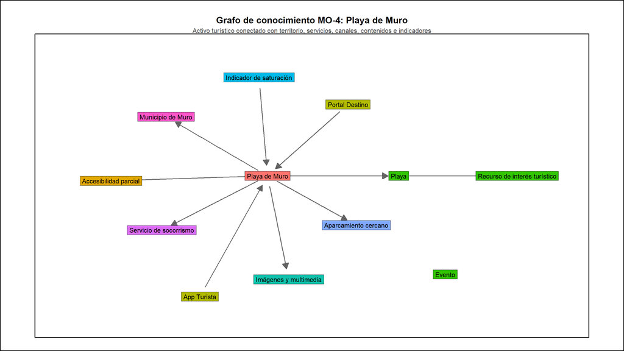

```r
# Posiciones manuales para reproducir el estilo de los PNG de referencia,
# ahora con fondo blanco y marco.
# La disposición coloca el activo turístico en el centro y distribuye
# servicios, canales, contenidos e indicadores alrededor.

posiciones_mo4 <- tribble(
  ~id,                       ~x,    ~y,
  "mo4:PlayaDeMuro",          0.0,   0.0,
  "seg:Playa",                3.1,   0.0,
  "seg:RecursoTuristico",     5.9,   0.0,
  "seg:Evento",               4.2,  -2.0,
  "mo4:MunicipioMuro",       -2.4,   1.2,
  "mo4:Socorrismo",          -2.5,  -1.1,
  "mo4:Aparcamiento",         2.1,  -1.0,
  "mo4:Accesibilidad",       -3.7,  -0.1,
  "mo4:Imagenes",             0.5,  -2.1,
  "mo4:AppTurista",          -1.6,  -2.45,
  "mo4:PortalDestino",        1.9,   1.45,
  "mo4:IndicadorSaturacion", -0.2,   2.0
)

nodes_plot <- nodes %>%
  left_join(posiciones_mo4, by = "id")

grafo_mo4_plot <- graph_from_data_frame(
  d = edges,
  vertices = nodes_plot,
  directed = TRUE
)

set.seed(123)

p_grafo_mo4 <- ggraph(
  grafo_mo4_plot,
  layout = "manual",
  x = V(grafo_mo4_plot)$x,
  y = V(grafo_mo4_plot)$y
) +
  geom_edge_link(
    arrow = grid::arrow(length = grid::unit(4, "mm"), type = "closed"),
    start_cap = circle(7, "mm"),
    end_cap = circle(7, "mm"),
    colour = "grey35",
    edge_width = 0.85,
    alpha = 0.9,
    show.legend = FALSE
  ) +
  geom_node_label(
    aes(label = label, fill = tipo),
    colour = "black",
    size = 4.2,
    label.padding = grid::unit(0.28, "lines"),
    label.r = grid::unit(0, "lines"),
    label.size = 0
  ) +
  scale_fill_manual(values = colores_tipo) +
  coord_cartesian(
    # Límites amplios: mantienen todas las etiquetas dentro del marco.
    xlim = c(-4.9, 7.0),
    ylim = c(-3.0, 2.6),
    clip = "off"
  ) +
  labs(
    title = "Grafo de conocimiento MO-4: Playa de Muro",
    subtitle = "Activo turístico conectado con territorio, servicios, canales, contenidos e indicadores"
  ) +
  tema_grafo_mo4()

p_grafo_mo4
```

```r
# Exportación opcional del PNG con fondo blanco y marco.
ggsave(
  filename = "grafo1_muro.png",
  plot = p_grafo_mo4,
  width = 16,
  height = 9,
  dpi = 300,
  bg = "white",
  limitsize = FALSE
)
```

## 6.2 Interpretación del grafo

El grafo representa de forma simplificada cómo un activo turístico concreto del catálogo MO-4, en este caso la **Playa de Muro**, puede vincularse con clases generales de una ontología turística, como `RecursoTuristico` o `Playa`, y con entidades operativas del destino, como servicios públicos, atributos de accesibilidad, contenidos multimedia, canales digitales e indicadores de gestión.

Este ejemplo permite mostrar la utilidad de una representación semántica basada en nodos y relaciones. El activo turístico no aparece como un registro aislado en una tabla, sino como una entidad conectada con otros elementos del sistema.

De este modo, la misma información puede ser reutilizada por diferentes componentes de la PID Mallorca, como el Portal Destino, la App Turista, los cuadros de mando, el asistente virtual o los módulos de análisis de saturación.

# 7 Lectura aplicada al módulo MO-4

En el contexto del módulo MO-4, este tipo de representación permite explicar que la digitalización de activos turísticos no consiste únicamente en guardar fichas descriptivas, imágenes o coordenadas geográficas.

La lógica del grafo permite conectar cada activo con:

- su categoría turística;
- su localización territorial;
- los servicios disponibles;
- sus atributos de accesibilidad;
- los contenidos multimedia asociados;
- los canales digitales donde se publica;
- los indicadores que permiten monitorizarlo.

Esta estructura facilita la interoperabilidad semántica porque diferentes sistemas pueden entender que la **Playa de Muro** es una playa, que forma parte de un municipio, que dispone de determinados servicios, que puede publicarse en canales digitales y que puede ser medida mediante indicadores de gestión.

# 8 Posible uso en la PID Mallorca

Este ejemplo puede trasladarse al diseño funcional del MO-4 como una forma sencilla de explicar la relación entre catálogo turístico, ontología, CMS semántico y servicios digitales.

En lugar de trabajar con información turística dispersa, el módulo MO-4 puede actuar como una infraestructura de datos en la que cada activo queda descrito, conectado y preparado para ser reutilizado por otros módulos de la PID.

Así, el grafo de conocimiento ayuda a convertir el catálogo turístico de Mallorca en una base interoperable para la publicación multicanal, la analítica turística, la recomendación personalizada y la toma de decisiones basada en datos.

## 8.1 Lectura del ejemplo

Este grafo permite interpretar el activo turístico de forma más rica que una tabla convencional.

En una tabla, **Playa de Muro** sería una fila con campos.

En el grafo, **Playa de Muro** es una entidad conectada con otras entidades:

- una clase ontológica;
- un municipio;
- servicios;
- atributos;
- contenidos;
- canales digitales;
- indicadores.

```r
# Relaciones directas del activo Playa de Muro.
relaciones_playa <- edges %>%
  filter(from == "mo4:PlayaDeMuro") %>%
  left_join(nodes, by = c("to" = "id"))

g <- graph_from_data_frame(
  d = relaciones_playa %>%
    select(from, to, relacion),
  vertices = nodes,
  directed = TRUE
)
g
```

```
## IGRAPH b27e3a5 DN-- 12 6 --
## + attr: name (v/c), label (v/c), tipo (v/c), relacion (e/c)
## + edges from b27e3a5 (vertex names):
## [1] mo4:PlayaDeMuro->seg:Playa         mo4:PlayaDeMuro->mo4:MunicipioMuro
## [3] mo4:PlayaDeMuro->mo4:Socorrismo    mo4:PlayaDeMuro->mo4:Aparcamiento
## [5] mo4:PlayaDeMuro->mo4:Accesibilidad mo4:PlayaDeMuro->mo4:Imagenes
```

## 8.2 Ejemplo de consulta analítica

Una ventaja del grafo es que permite hacer consultas sobre relaciones.

Por ejemplo, podemos preguntar:

> ¿Con qué entidades está conectada Playa de Muro?

```r
# Vecinos directos de Playa de Muro.
# mode = "out" indica que buscamos relaciones que salen desde Playa de Muro.

vecinos <- neighbors(
  graph = g ,
  v = "mo4:PlayaDeMuro",
  mode = "out"
)

V(g)[vecinos]$label
```

```
## [1] "Playa"                  "Municipio de Muro"      "Servicio de socorrismo"
## [4] "Aparcamiento cercano"   "Accesibilidad parcial"  "Imágenes y multimedia"
```

También podemos calcular qué nodos tienen más conexiones.

```r
# Grado de salida: número de relaciones que salen de cada nodo.
# En este ejemplo, Playa de Muro tendrá muchas relaciones porque es el activo central.

grado_salida <- tibble(
  id = V(g)$name,
  label = V(g)$label,
  tipo = V(g)$tipo,
  grado_salida = degree(g, mode = "out")
) %>%
  arrange(desc(grado_salida))

grado_salida
```

```
## # A tibble: 12 × 4
##    id                      label                        tipo        grado_salida
##    <chr>                   <chr>                        <chr>              <dbl>
##  1 mo4:PlayaDeMuro         Playa de Muro                Activo MO-4            6
##  2 seg:RecursoTuristico    Recurso de interés turístico Clase onto…            0
##  3 seg:Playa               Playa                        Clase onto…            0
##  4 seg:Evento              Evento                       Clase onto…            0
##  5 mo4:MunicipioMuro       Municipio de Muro            Territorio             0
##  6 mo4:Socorrismo          Servicio de socorrismo       Servicio p…            0
##  7 mo4:Aparcamiento        Aparcamiento cercano         Servicio               0
##  8 mo4:Accesibilidad       Accesibilidad parcial        Atributo               0
##  9 mo4:Imagenes            Imágenes y multimedia        Contenido              0
## 10 mo4:AppTurista          App Turista                  Canal digi…            0
## 11 mo4:PortalDestino       Portal Destino               Canal digi…            0
## 12 mo4:IndicadorSaturacion Indicador de saturación      Indicador              0
```

En un grafo real del MO-4, este tipo de análisis permitiría detectar:

- activos muy conectados;
- activos poco documentados;
- municipios con baja cobertura;
- recursos sin localización;
- activos sin contenidos multimedia;
- servicios turísticos no vinculados a canales digitales;
- zonas con muchos recursos pero pocos servicios asociados.

# 9 Validación mínima de calidad del dato

Una ontología no solo sirve para clasificar. También ayuda a definir qué datos mínimos debería tener cada activo.

Por ejemplo, una ficha mínima de activo turístico podría exigir:

- clase o tipo de activo;
- municipio;
- localización;
- descripción;
- canal de publicación;
- estado de actualización.

Aquí se muestra una validación muy sencilla.

```r
# Definimos las relaciones mínimas esperadas para un activo turístico.
# Esto es un ejemplo simplificado.
# En una implementación real podrían usarse reglas SHACL sobre RDF.

relaciones_minimas <- c(
  "es_un_tipo_de",
  "esta_en",
  "se_publica_en"
)

# Extraemos las relaciones disponibles para Playa de Muro.

relaciones_disponibles <- edges %>%
  filter(from == "mo4:PlayaDeMuro") %>%
  pull(relacion)

# Comprobamos qué relaciones mínimas faltan.

relaciones_faltantes <- setdiff(
  relaciones_minimas,
  relaciones_disponibles
)

if (length(relaciones_faltantes) == 0) {
  print("El activo cumple las relaciones mínimas del ejemplo.")
} else {
  print("Faltan relaciones mínimas:")
  print(relaciones_faltantes)
}
```

```
## [1] "Faltan relaciones mínimas:"
## [1] "esta_en"       "se_publica_en"
```

## 9.1 Ejemplo de ampliación con otro activo

Ahora añadimos un segundo activo, por ejemplo un evento.

Esto permite mostrar cómo el grafo crece conectando activos entre sí y cómo puede apoyar análisis entre módulos. En este caso, el evento se conecta con el municipio, con la playa y con el indicador de saturación, por lo que queda más claro cómo un hecho puntual puede modificar la gestión operativa del destino.

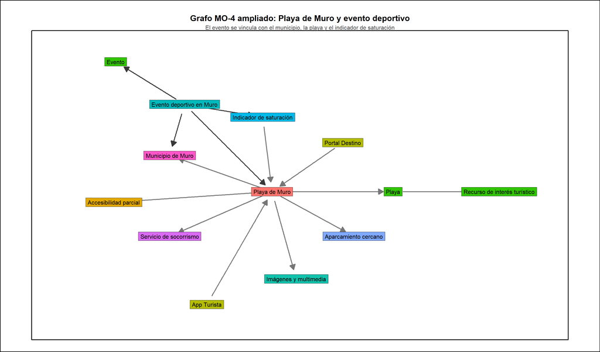

```r
# Nuevo nodo: evento turístico o cultural.

nuevo_nodo <- tribble(
  ~id,                         ~label,                         ~tipo,
  "mo4:EventoDeportivoMuro",   "Evento deportivo en Muro",     "Evento MO-4"
)

# Nuevas relaciones del evento.

nuevas_relaciones <- tribble(
  ~from,                        ~to,                         ~relacion,
  "mo4:EventoDeportivoMuro",    "seg:Evento",                "es_un_tipo_de",
  "mo4:EventoDeportivoMuro",    "mo4:MunicipioMuro",         "se_celebra_en",
  "mo4:EventoDeportivoMuro",    "mo4:PlayaDeMuro",           "afecta_a",
  "mo4:EventoDeportivoMuro",    "mo4:IndicadorSaturacion",   "puede_modificar"
)

# Combinamos nodos y relaciones.

nodes_2 <- bind_rows(nodes, nuevo_nodo)
edges_2 <- bind_rows(edges, nuevas_relaciones) %>%
  mutate(
    grupo_relacion = if_else(
      from == "mo4:EventoDeportivoMuro",
      "Relaciones añadidas por el evento",
      "Relaciones del activo turístico"
    )
  )

# Posiciones manuales del grafo ampliado.
# Se deja margen suficiente a izquierda, derecha, arriba y abajo
# para que ninguna etiqueta quede recortada al renderizar o exportar.

posiciones_mo4_evento <- tribble(
  ~id,                         ~x,    ~y,
  "seg:Evento",                -4.2,   3.05,
  "mo4:EventoDeportivoMuro",   -2.35,  2.05,
  "mo4:IndicadorSaturacion",   -0.25,  1.75,
  "mo4:MunicipioMuro",         -2.75,  0.85,
  "mo4:PlayaDeMuro",            0.0,   0.0,
  "seg:Playa",                  3.25,  0.0,
  "seg:RecursoTuristico",       6.1,   0.0,
  "mo4:Socorrismo",            -2.75, -1.05,
  "mo4:Aparcamiento",           2.2,  -1.05,
  "mo4:Accesibilidad",         -4.25, -0.25,
  "mo4:Imagenes",               0.65, -2.05,
  "mo4:AppTurista",            -1.75, -2.65,
  "mo4:PortalDestino",          1.9,   1.15
)

nodes_2_plot <- nodes_2 %>%
  left_join(posiciones_mo4_evento, by = "id")

# Reconstruimos el grafo ampliado.

g2 <- graph_from_data_frame(
  d = edges_2,
  vertices = nodes_2_plot,
  directed = TRUE
)

set.seed(123)

p_grafo_mo4_evento <- ggraph(
  g2,
  layout = "manual",
  x = V(g2)$x,
  y = V(g2)$y
) +
  geom_edge_link(
    aes(edge_colour = grupo_relacion),
    arrow = grid::arrow(length = grid::unit(4, "mm"), type = "closed"),
    start_cap = circle(7, "mm"),
    end_cap = circle(7, "mm"),
    edge_width = 0.9,
    alpha = 0.95,
    show.legend = FALSE
  ) +
  geom_node_label(
    aes(label = label, fill = tipo),
    colour = "black",
    size = 4.25,
    label.padding = grid::unit(0.30, "lines"),
    label.r = grid::unit(0, "lines"),
    label.size = 0
  ) +
  scale_fill_manual(values = colores_tipo) +
  scale_edge_colour_manual(
    values = c(
      "Relaciones del activo turístico" = "grey45",
      "Relaciones añadidas por el evento" = "grey20"
    )
  ) +
  coord_cartesian(
    # Límites amplios: el evento añadido y sus etiquetas quedan dentro del marco.
    xlim = c(-5.8, 7.3),
    ylim = c(-3.15, 3.45),
    clip = "off"
  ) +
  labs(
    title = "Grafo MO-4 ampliado: Playa de Muro y evento deportivo",
    subtitle = "El evento se vincula con el municipio, la playa y el indicador de saturación"
  ) +
  tema_grafo_mo4()

p_grafo_mo4_evento
```

```r
# Guardar el grafo como PNG con fondo blanco, marco y tamaño amplio para evitar recortes.

ggsave(
  filename = "grafo_mo4_ampliado_evento.png",
  plot = p_grafo_mo4_evento,
  width = 17,
  height = 10,
  dpi = 300,
  bg = "white",
  limitsize = FALSE
)
```

## 9.2 Consulta sobre el grafo ampliado

Ahora podemos preguntar:

> ¿Qué activos o indicadores se ven afectados por el evento?

```r
relaciones_evento <- edges_2 %>%
  filter(from == "mo4:EventoDeportivoMuro") %>%
  left_join(nodes_2, by = c("to" = "id")) %>%
  select(
    evento = from,
    relacion,
    entidad_relacionada = label,
    tipo_entidad = tipo
  )

relaciones_evento
```

```
## # A tibble: 4 × 4
##   evento                  relacion        entidad_relacionada     tipo_entidad
##   <chr>                   <chr>           <chr>                   <chr>
## 1 mo4:EventoDeportivoMuro es_un_tipo_de   Evento                  Clase ontológ…
## 2 mo4:EventoDeportivoMuro se_celebra_en   Municipio de Muro       Territorio
## 3 mo4:EventoDeportivoMuro afecta_a        Playa de Muro           Activo MO-4
## 4 mo4:EventoDeportivoMuro puede_modificar Indicador de saturación Indicador
```

Este ejemplo conecta directamente con una lectura operativa de la PID Mallorca: los eventos no son solo registros de agenda, sino elementos que pueden afectar a saturación, movilidad, recursos turísticos, servicios públicos y planificación territorial.

## 9.3 Lectura por actores del proyecto

El mismo grafo puede ser útil para perfiles distintos.

```r
lectura_actores <- tribble(
  ~actor, ~lectura_del_grafo,
  "T2C / equipo técnico",
  "Permite diseñar datos estructurados, identificadores, clases, propiedades, APIs, validaciones e integraciones con CMS o servicios comunes.",
  "Universidad / computación estadística",
  "Permite analizar relaciones, calidad del dato, cobertura territorial, activos poco documentados, indicadores de saturación y modelos predictivos.",
  "Economistas de turismo",
  "Permite interpretar el activo como parte de la oferta turística, conectado con movilidad, gasto, alojamiento, eventos, presión territorial y experiencia del visitante.",
  "Fundació / Consell / técnicos públicos",
  "Permite gobernar mejor el catálogo: saber qué existe, qué falta, quién mantiene cada dato, qué se publica y qué decisiones pueden justificarse.",
  "Sector turístico",
  "Permite reutilizar información fiable para productos, recomendaciones, rutas, paquetes, servicios y atención al visitante."
)

lectura_actores
```

```
## # A tibble: 5 × 2
##   actor                                  lectura_del_grafo
##   <chr>                                  <chr>
## 1 T2C / equipo técnico                   Permite diseñar datos estructurados, i…
## 2 Universidad / computación estadística  Permite analizar relaciones, calidad d…
## 3 Economistas de turismo                 Permite interpretar el activo como par…
## 4 Fundació / Consell / técnicos públicos Permite gobernar mejor el catálogo: sa…
## 5 Sector turístico                       Permite reutilizar información fiable …
```

## 9.4 Interpretación para el MO-4

El ejemplo anterior muestra que el grafo permite conectar distintos módulos y problemas de gestión.

Una playa puede estar relacionada con:

- un municipio;
- servicios públicos;
- canales de publicación;
- indicadores de saturación;
- eventos próximos;
- información de movilidad;
- contenidos multimedia;
- datos de accesibilidad.

Esto permite pasar de una visión de inventario a una visión de sistema.

Para el MO-4, esta lógica es importante porque el catálogo de activos turísticos puede alimentar otros servicios de la PID:

- Portal Destino;
- App Turista;
- Asistente Virtual;
- cuadros de mando;
- módulos de localización;
- análisis de flujos y saturación;
- evaluación del impacto de eventos.

# 10 Conclusión del ejemplo

Este anexo no pretende reproducir la arquitectura técnica completa de la PID. En una implementación real, la representación semántica podría apoyarse en RDF, OWL, SKOS, SHACL, SPARQL y un triplestore como Virtuoso.

El ejemplo sirve para mostrar la lógica de fondo:

1. La ontología define las clases, propiedades y relaciones.
2. El catálogo MO-4 contiene los activos concretos.
3. El grafo conecta esos activos con territorio, servicios, indicadores y canales.
4. La universidad puede explotar esa estructura para análisis estadístico, calidad del dato y modelos.
5. El equipo técnico puede implementarla mediante APIs, CMS semántico y servicios interoperables.
6. La administración puede utilizarla para gobernar mejor la información turística del destino.

En síntesis:

> La ontología aporta el lenguaje común del destino.  
> El grafo convierte ese lenguaje en una red de datos reales, reutilizable para gestión, análisis y servicios turísticos inteligentes.